# Mobile App Store ( 7200 apps) 資料集分析

## 資料來源

[Kaggle dataset: Mobile App Store(7200 apps)](https://www.kaggle.com/ramamet4/app-store-apple-data-set-10k-apps)

## 資料欄位內容

### appleStore.csv

- id: App ID
- track_name: App Name
- size_bytes: Size (in Bytes)
- currency: Currency Type
- price: Price amount
- rating_count_tot: User Rating counts (for all version)
- rating_count_ver: User Rating counts (for current version)
- user_rating: Average User Rating value (for all version)
- user_rating_ver: Average User Rating value (for current version)
- ver: Latest version code
- cont_ratin": Content Rating
- prime_genre: Primary Genre
- sup_devices.num: Number of supporting devices
- ipadSc_urls.num: Number of screenshots showed for display
- lang.num: Number of supported languages
- vpp_lic: Vpp Device Based Licensing Enabled

### appleStore_description.csv

- id : App ID
- track_name: Application name
- size_bytes: Memory size (in Bytes)
- app_desc: Application description

## 分析流程：

- 資料取得
- 資料前處理
- 資料探索
- 分析

## 欲分析問題

- 不同類型的 App 之下，是否付費的會得到較高的評分？
- App 類型是否會影響收益？

# 資料取得

## 載入 library

```python
import pandas as pd
import numpy as np
from matplotlib import pyplot as plt
import seaborn as sns
%matplotlib inline
plt.rcParams['figure.figsize'] = [20, 20]
```

## 載入資料

```python
app_df = pd.read_csv('./input/AppleStore.csv', sep=",", header=0)
description_df = pd.read_csv('./input/appleStore_description.csv', sep=",", header=0)
```

```python
app_df.head()
```

|  | Unnamed: 0 | id | track_name | size_bytes | currency | price | rating_count_tot | rating_count_ver | user_rating | user_rating_ver | ver | cont_rating | prime_genre | sup_devices.num | ipadSc_urls.num | lang.num | vpp_lic |
| --- | --- | --- | --- | --- | --- | --- | --- | --- | --- | --- | --- | --- | --- | --- | --- | --- | --- |
| 0 | 1 | 281656475 | PAC-MAN Premium | 100788224 | USD | 3.99 | 21292 | 26 | 4.0 | 4.5 | 6.3.5 | 4+ | Games | 38 | 5 | 10 | 1 |
| 1 | 2 | 281796108 | Evernote - stay organized | 158578688 | USD | 0.00 | 161065 | 26 | 4.0 | 3.5 | 8.2.2 | 4+ | Productivity | 37 | 5 | 23 | 1 |
| 2 | 3 | 281940292 | WeatherBug - Local Weather, Radar, Maps, Alerts | 100524032 | USD | 0.00 | 188583 | 2822 | 3.5 | 4.5 | 5.0.0 | 4+ | Weather | 37 | 5 | 3 | 1 |
| 3 | 4 | 282614216 | eBay: Best App to Buy, Sell, Save! Online Shop... | 128512000 | USD | 0.00 | 262241 | 649 | 4.0 | 4.5 | 5.10.0 | 12+ | Shopping | 37 | 5 | 9 | 1 |
| 4 | 5 | 282935706 | Bible | 92774400 | USD | 0.00 | 985920 | 5320 | 4.5 | 5.0 | 7.5.1 | 4+ | Reference | 37 | 5 | 45 | 1 |

```python
print("App Store data 的 size {0}".format(app_df.shape))
```

```
App Store data 的 size (7197, 17)
```

```python
description_df.head()
```

|  | id | track_name | size_bytes | app_desc |
| --- | --- | --- | --- | --- |
| 0 | 281656475 | PAC-MAN Premium | 100788224 | SAVE 20%, now only $3.99 for a limited time!\n... |
| 1 | 281796108 | Evernote - stay organized | 158578688 | Let Evernote change the way you organize your ... |
| 2 | 281940292 | WeatherBug - Local Weather, Radar, Maps, Alerts | 100524032 | Download the most popular free weather app pow... |
| 3 | 282614216 | eBay: Best App to Buy, Sell, Save! Online Shop... | 128512000 | The eBay app is the best way to find anything ... |
| 4 | 282935706 | Bible | 92774400 | On more than 250 million devices around the wo... |

```python
print("App Store description data 的 size {0}".format(description_df.shape))
```

```
App Store description data 的 size (7197, 4)
```

# 資料前處理

## 數據清理

觀察兩個 dataset 的size可發現 row number 相同，下一步先將其合併

```python
combined_app_data= pd.merge(app_df,description_df, how = "left")
```

並觀察資料，發現 id 欄位為 App ID 且為唯一，故將其設為 row id

```python
combined_app_data.set_index('id', inplace = True)
```

```python
combined_app_data.head()
```

| id | Unnamed: 0 | track_name | size_bytes | currency | price | rating_count_tot | rating_count_ver | user_rating | user_rating_ver | ver | cont_rating | prime_genre | sup_devices.num | ipadSc_urls.num | lang.num | vpp_lic | app_desc |
| --- | --- | --- | --- | --- | --- | --- | --- | --- | --- | --- | --- | --- | --- | --- | --- | --- | --- |
| 281656475 | 1 | PAC-MAN Premium | 100788224 | USD | 3.99 | 21292 | 26 | 4.0 | 4.5 | 6.3.5 | 4+ | Games | 38 | 5 | 10 | 1 | SAVE 20%, now only $3.99 for a limited time!\n... |
| 281796108 | 2 | Evernote - stay organized | 158578688 | USD | 0.00 | 161065 | 26 | 4.0 | 3.5 | 8.2.2 | 4+ | Productivity | 37 | 5 | 23 | 1 | Let Evernote change the way you organize your ... |
| 281940292 | 3 | WeatherBug - Local Weather, Radar, Maps, Alerts | 100524032 | USD | 0.00 | 188583 | 2822 | 3.5 | 4.5 | 5.0.0 | 4+ | Weather | 37 | 5 | 3 | 1 | Download the most popular free weather app pow... |
| 282614216 | 4 | eBay: Best App to Buy, Sell, Save! Online Shop... | 128512000 | USD | 0.00 | 262241 | 649 | 4.0 | 4.5 | 5.10.0 | 12+ | Shopping | 37 | 5 | 9 | 1 | The eBay app is the best way to find anything ... |
| 282935706 | 5 | Bible | 92774400 | USD | 0.00 | 985920 | 5320 | 4.5 | 5.0 | 7.5.1 | 4+ | Reference | 37 | 5 | 45 | 1 | On more than 250 million devices around the wo... |

觀察資料，發現 Unnamed: 0 column 是多餘的，將其刪除

```python
combined_app_data=combined_app_data.drop("Unnamed: 0", axis=1)
```

```python
combined_app_data.head()
```

| id | track_name | size_bytes | currency | price | rating_count_tot | rating_count_ver | user_rating | user_rating_ver | ver | cont_rating | prime_genre | sup_devices.num | ipadSc_urls.num | lang.num | vpp_lic | app_desc |
| --- | --- | --- | --- | --- | --- | --- | --- | --- | --- | --- | --- | --- | --- | --- | --- | --- |
| 281656475 | PAC-MAN Premium | 100788224 | USD | 3.99 | 21292 | 26 | 4.0 | 4.5 | 6.3.5 | 4+ | Games | 38 | 5 | 10 | 1 | SAVE 20%, now only $3.99 for a limited time!\n... |
| 281796108 | Evernote - stay organized | 158578688 | USD | 0.00 | 161065 | 26 | 4.0 | 3.5 | 8.2.2 | 4+ | Productivity | 37 | 5 | 23 | 1 | Let Evernote change the way you organize your ... |
| 281940292 | WeatherBug - Local Weather, Radar, Maps, Alerts | 100524032 | USD | 0.00 | 188583 | 2822 | 3.5 | 4.5 | 5.0.0 | 4+ | Weather | 37 | 5 | 3 | 1 | Download the most popular free weather app pow... |
| 282614216 | eBay: Best App to Buy, Sell, Save! Online Shop... | 128512000 | USD | 0.00 | 262241 | 649 | 4.0 | 4.5 | 5.10.0 | 12+ | Shopping | 37 | 5 | 9 | 1 | The eBay app is the best way to find anything ... |
| 282935706 | Bible | 92774400 | USD | 0.00 | 985920 | 5320 | 4.5 | 5.0 | 7.5.1 | 4+ | Reference | 37 | 5 | 45 | 1 | On more than 250 million devices around the wo... |

尋找是否有缺失值存在資料中

```python
combined_app_data.isna().sum()
```

```
track_name          0
size_bytes          0
currency            0
price               0
rating_count_tot    0
rating_count_ver    0
user_rating         0
user_rating_ver     0
ver                 0
cont_rating         0
prime_genre         0
sup_devices.num     0
ipadSc_urls.num     0
lang.num            0
vpp_lic             0
app_desc            0
dtype: int64
```

無缺失值存在資料中

接著，為了後續分析方便，加上 Category 欄位，標示為 Free app 或 Paid app

```python
combined_app_data["Category"]= np.where(combined_app_data.price==0.00, "Free app", "Paid app")
```

```python
print("免費 app 個數為：{0}".format(len(combined_app_data[combined_app_data["Category"] == "Free app"])))
```

```
免費 app 個數為：4056
```

```python
print("付費 app 個數為：{0}".format(len(combined_app_data[combined_app_data["Category"] == "Paid app"])))
```

```
付費 app 個數為：3141
```

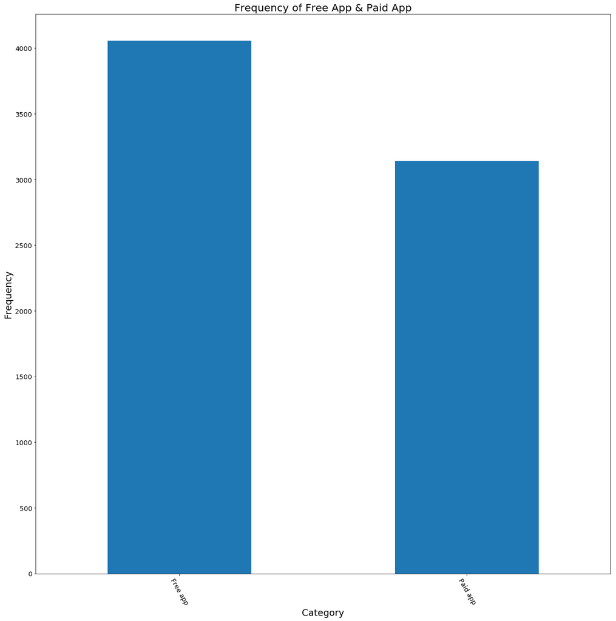

```python
combined_app_data.Category.value_counts().plot(kind="bar")
plt.title("Frequency of Free App & Paid App", fontsize=20)
plt.xlabel("Category", fontsize=18)
plt.ylabel("Frequency", fontsize=18)
plt.yticks(fontsize=13)
plt.xticks(fontsize=13,rotation=(-60))
plt.show()
```

為了後續分析方便，加上 description_len ，內容為 description 的長度

```python
combined_app_data["desc_len"] = combined_app_data["app_desc"].apply(lambda x: len(x))
combined_app_data.head()
```

| id | track_name | size_bytes | currency | price | rating_count_tot | rating_count_ver | user_rating | user_rating_ver | ver | cont_rating | prime_genre | sup_devices.num | ipadSc_urls.num | lang.num | vpp_lic | app_desc | Category | desc_len |
| --- | --- | --- | --- | --- | --- | --- | --- | --- | --- | --- | --- | --- | --- | --- | --- | --- | --- | --- |
| 281656475 | PAC-MAN Premium | 100788224 | USD | 3.99 | 21292 | 26 | 4.0 | 4.5 | 6.3.5 | 4+ | Games | 38 | 5 | 10 | 1 | SAVE 20%, now only $3.99 for a limited time!\n... | Paid app | 1533 |
| 281796108 | Evernote - stay organized | 158578688 | USD | 0.00 | 161065 | 26 | 4.0 | 3.5 | 8.2.2 | 4+ | Productivity | 37 | 5 | 23 | 1 | Let Evernote change the way you organize your ... | Free app | 3952 |
| 281940292 | WeatherBug - Local Weather, Radar, Maps, Alerts | 100524032 | USD | 0.00 | 188583 | 2822 | 3.5 | 4.5 | 5.0.0 | 4+ | Weather | 37 | 5 | 3 | 1 | Download the most popular free weather app pow... | Free app | 2090 |
| 282614216 | eBay: Best App to Buy, Sell, Save! Online Shop... | 128512000 | USD | 0.00 | 262241 | 649 | 4.0 | 4.5 | 5.10.0 | 12+ | Shopping | 37 | 5 | 9 | 1 | The eBay app is the best way to find anything ... | Free app | 3997 |
| 282935706 | Bible | 92774400 | USD | 0.00 | 985920 | 5320 | 4.5 | 5.0 | 7.5.1 | 4+ | Reference | 37 | 5 | 45 | 1 | On more than 250 million devices around the wo... | Free app | 2998 |

各變數的敘述統計量

```python
combined_app_data.describe()
```

|  | size_bytes | price | rating_count_tot | rating_count_ver | user_rating | user_rating_ver | sup_devices.num | ipadSc_urls.num | lang.num | vpp_lic | desc_len |
| --- | --- | --- | --- | --- | --- | --- | --- | --- | --- | --- | --- |
| count | 7.197000e+03 | 7197.000000 | 7.197000e+03 | 7197.000000 | 7197.000000 | 7197.000000 | 7197.000000 | 7197.000000 | 7197.000000 | 7197.000000 | 7197.000000 |
| mean | 1.991345e+08 | 1.726218 | 1.289291e+04 | 460.373906 | 3.526956 | 3.253578 | 37.361817 | 3.707100 | 5.434903 | 0.993053 | 1553.714186 |
| std | 3.592069e+08 | 5.833006 | 7.573941e+04 | 3920.455183 | 1.517948 | 1.809363 | 3.737715 | 1.986005 | 7.919593 | 0.083066 | 1010.574457 |
| min | 5.898240e+05 | 0.000000 | 0.000000e+00 | 0.000000 | 0.000000 | 0.000000 | 9.000000 | 0.000000 | 0.000000 | 0.000000 | 17.000000 |
| 25% | 4.692275e+07 | 0.000000 | 2.800000e+01 | 1.000000 | 3.500000 | 2.500000 | 37.000000 | 3.000000 | 1.000000 | 1.000000 | 737.000000 |
| 50% | 9.715302e+07 | 0.000000 | 3.000000e+02 | 23.000000 | 4.000000 | 4.000000 | 37.000000 | 5.000000 | 1.000000 | 1.000000 | 1366.000000 |
| 75% | 1.819249e+08 | 1.990000 | 2.793000e+03 | 140.000000 | 4.500000 | 4.500000 | 38.000000 | 5.000000 | 8.000000 | 1.000000 | 2190.000000 |
| max | 4.025970e+09 | 299.990000 | 2.974676e+06 | 177050.000000 | 5.000000 | 5.000000 | 47.000000 | 5.000000 | 75.000000 | 1.000000 | 4000.000000 |

# 資料探索

各資料集內的欄位

```python
combined_app_data.columns
```

```
Index(['track_name', 'size_bytes', 'currency', 'price', 'rating_count_tot',
       'rating_count_ver', 'user_rating', 'user_rating_ver', 'ver',
       'cont_rating', 'prime_genre', 'sup_devices.num', 'ipadSc_urls.num',
       'lang.num', 'vpp_lic', 'app_desc', 'Category', 'desc_len'],
      dtype='object')
```

## Scatter Matrix

```
array([[<matplotlib.axes._subplots.AxesSubplot object at 0x1a217863c8>,
      dtype=object)
```

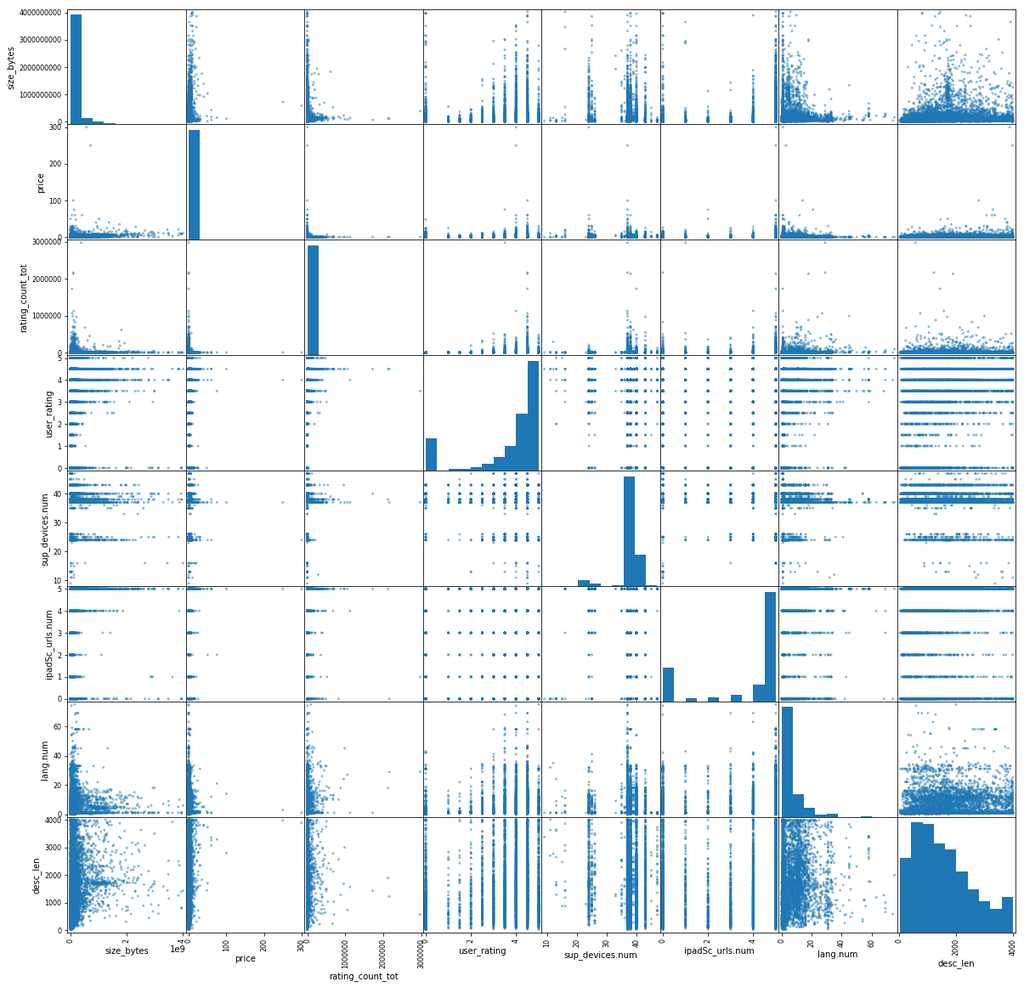

```python
pd.plotting.scatter_matrix(combined_app_data[['size_bytes', 'price',
       'rating_count_tot', 'user_rating', 'ver',
       'sup_devices.num', 'ipadSc_urls.num', 'lang.num', 'desc_len']])
```

取出幾個感興趣的 feature，透過 scatter matrix 可看出並無特別的趨勢或相關性。

## 觀察 feature 間的相關性

```python
corr_app_df = combined_app_data.corr()
corr_app_df
```

|  | size_bytes | price | rating_count_tot | rating_count_ver | user_rating | user_rating_ver | sup_devices.num | ipadSc_urls.num | lang.num | vpp_lic | desc_len |
| --- | --- | --- | --- | --- | --- | --- | --- | --- | --- | --- | --- |
| size_bytes | 1.000000 | 0.182392 | 0.004486 | 0.006337 | 0.066256 | 0.086075 | -0.118347 | 0.152697 | 0.004614 | -0.150418 | 0.129596 |
| price | 0.182392 | 1.000000 | -0.039044 | -0.018012 | 0.046601 | 0.025173 | -0.115361 | 0.066100 | -0.006713 | -0.029942 | 0.167534 |
| rating_count_tot | 0.004486 | -0.039044 | 1.000000 | 0.163645 | 0.083310 | 0.088744 | 0.008832 | 0.015734 | 0.137675 | -0.000982 | 0.050831 |
| rating_count_ver | 0.006337 | -0.018012 | 0.163645 | 1.000000 | 0.068754 | 0.077840 | 0.037951 | 0.024333 | 0.013287 | 0.006460 | 0.016941 |
| user_rating | 0.066256 | 0.046601 | 0.083310 | 0.068754 | 1.000000 | 0.774140 | -0.042451 | 0.265671 | 0.170976 | 0.069816 | 0.273644 |
| user_rating_ver | 0.086075 | 0.025173 | 0.088744 | 0.077840 | 0.774140 | 1.000000 | -0.018901 | 0.275737 | 0.175580 | 0.050094 | 0.248108 |
| sup_devices.num | -0.118347 | -0.115361 | 0.008832 | 0.037951 | -0.042451 | -0.018901 | 1.000000 | -0.037728 | -0.041681 | -0.037109 | -0.097072 |
| ipadSc_urls.num | 0.152697 | 0.066100 | 0.015734 | 0.024333 | 0.265671 | 0.275737 | -0.037728 | 1.000000 | 0.088378 | 0.071901 | 0.193143 |
| lang.num | 0.004614 | -0.006713 | 0.137675 | 0.013287 | 0.170976 | 0.175580 | -0.041681 | 0.088378 | 1.000000 | 0.032477 | 0.162522 |
| vpp_lic | -0.150418 | -0.029942 | -0.000982 | 0.006460 | 0.069816 | 0.050094 | -0.037109 | 0.071901 | 0.032477 | 1.000000 | 0.021883 |
| desc_len | 0.129596 | 0.167534 | 0.050831 | 0.016941 | 0.273644 | 0.248108 | -0.097072 | 0.193143 | 0.162522 | 0.021883 | 1.000000 |

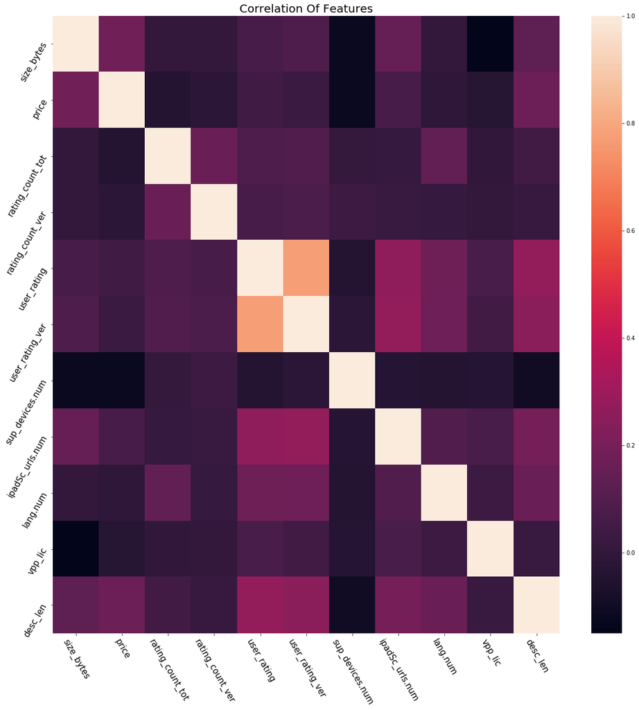

```python
plt.figure()
plt.title("Correlation Of Features", fontsize=20)
sns.heatmap(corr_app_df)
plt.xticks(rotation=(-60), fontsize=15)
plt.yticks(rotation=(60), fontsize=15)
plt.show()
```

"user_rating" 與 "user_rating_ver" 之間的 correlation 大於 0.5。但 user_rating_ver 為目前版本的平均評分，user_rating 為所有版本的平均評分，兩者之間本來就相關性高。

由此可知，此資料集 feature 間並無共線性問題要處理。

### 觀察各 feature 的資料型別

```python
combined_app_data.info()
```

```
<class 'pandas.core.frame.DataFrame'>
Int64Index: 7197 entries, 281656475 to 1188375727
Data columns (total 18 columns):
track_name          7197 non-null object
size_bytes          7197 non-null int64
currency            7197 non-null object
price               7197 non-null float64
rating_count_tot    7197 non-null int64
rating_count_ver    7197 non-null int64
user_rating         7197 non-null float64
user_rating_ver     7197 non-null float64
ver                 7197 non-null object
cont_rating         7197 non-null object
prime_genre         7197 non-null object
sup_devices.num     7197 non-null int64
ipadSc_urls.num     7197 non-null int64
lang.num            7197 non-null int64
vpp_lic             7197 non-null int64
app_desc            7197 non-null object
Category            7197 non-null object
desc_len            7197 non-null int64
dtypes: float64(3), int64(8), object(7)
memory usage: 1.0+ MB
```

```python
data_type_df=combined_app_data.dtypes.value_counts()
data_type_df
```

```
int64      8
object     7
float64    3
dtype: int64
```

可看出其中 int 64 有 8個 column, object 有 7個 column, float64 有3個 column

### 所有版本評分總個數排序

```python
rating_count_sorted = combined_app_data.sort_values(by="rating_count_tot", ascending=False).head(10).reset_index()
rating_count_sorted.loc[:, ["track_name", "rating_count_tot"]].T
```

|  | 0 | 1 | 2 | 3 | 4 | 5 | 6 | 7 | 8 | 9 |
| --- | --- | --- | --- | --- | --- | --- | --- | --- | --- | --- |
| track_name | Facebook | Instagram | Clash of Clans | Temple Run | Pandora - Music & Radio | Pinterest | Bible | Candy Crush Saga | Spotify Music | Angry Birds |
| rating_count_tot | 2974676 | 2161558 | 2130805 | 1724546 | 1126879 | 1061624 | 985920 | 961794 | 878563 | 824451 |

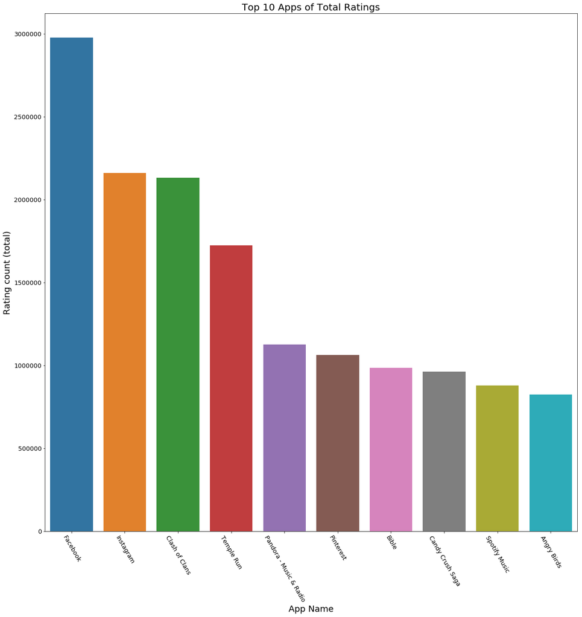

```python
sns.barplot(x=rating_count_sorted.track_name, y=rating_count_sorted.rating_count_tot)
plt.title("Top 10 Apps of Total Ratings", fontsize=20)
plt.xlabel("App Name", fontsize=18)
plt.ylabel("Rating count (total)", fontsize=18)
plt.yticks(fontsize=13)
plt.xticks(fontsize=13,rotation=(-60))
plt.show()
```

### 價格排序

```python
price_sorted = combined_app_data.sort_values(by="price", ascending=False).head(10).reset_index()
price_sorted.loc[:, ["track_name", "price"]].T
```

|  | 0 | 1 | 2 | 3 | 4 | 5 | 6 | 7 | 8 | 9 |
| --- | --- | --- | --- | --- | --- | --- | --- | --- | --- | --- |
| track_name | LAMP Words For Life | Proloquo2Go - Symbol-based AAC | KNFB Reader | NAVIGON Europe | FineScanner Pro - PDF Document Scanner App + OCR | Articulation Station Pro | Articulation Test Center Pro | VPN Pro \| Lifetime Proxy & Best VPN by Betternet | Cubasis 2 - Mobile Music Creation System | プチ・ロワイヤル仏和辞典（第4版）・和仏辞典（第3版） |
| price | 299.99 | 249.99 | 99.99 | 74.99 | 59.99 | 59.99 | 59.99 | 49.99 | 49.99 | 47.99 |

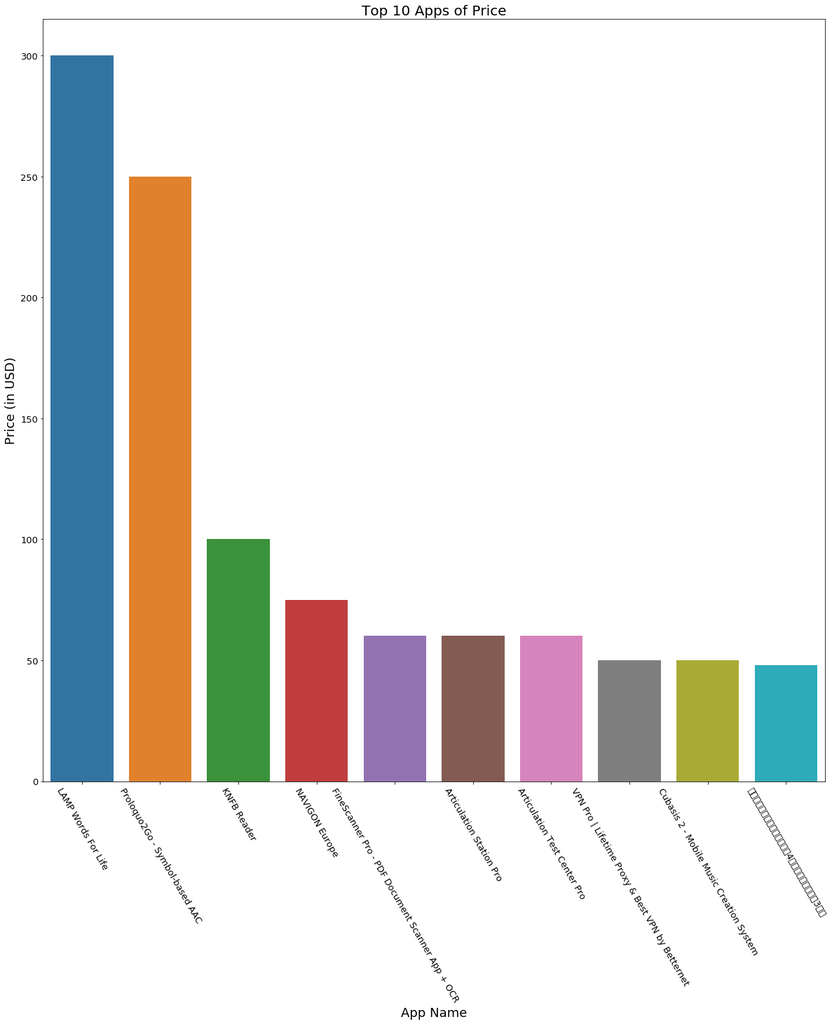

```python
sns.barplot(x=price_sorted.track_name, y=price_sorted.price)
plt.title("Top 10 Apps of Price", fontsize=20)
plt.xlabel("App Name", fontsize=18)
plt.ylabel("Price (in USD)", fontsize=18)
plt.yticks(fontsize=13)
plt.xticks(fontsize=13,rotation=(-60))
plt.show()
```

### Prime_genre 的個數排序

```python
combined_app_data.prime_genre.value_counts().reset_index()
```

|  | index | prime_genre |
| --- | --- | --- |
| 0 | Games | 3862 |
| 1 | Entertainment | 535 |
| 2 | Education | 453 |
| 3 | Photo & Video | 349 |
| 4 | Utilities | 248 |
| 5 | Health & Fitness | 180 |
| 6 | Productivity | 178 |
| 7 | Social Networking | 167 |
| 8 | Lifestyle | 144 |
| 9 | Music | 138 |
| 10 | Shopping | 122 |
| 11 | Sports | 114 |
| 12 | Book | 112 |
| 13 | Finance | 104 |
| 14 | Travel | 81 |
| 15 | News | 75 |
| 16 | Weather | 72 |
| 17 | Reference | 64 |
| 18 | Food & Drink | 63 |
| 19 | Business | 57 |
| 20 | Navigation | 46 |
| 21 | Medical | 23 |
| 22 | Catalogs | 10 |

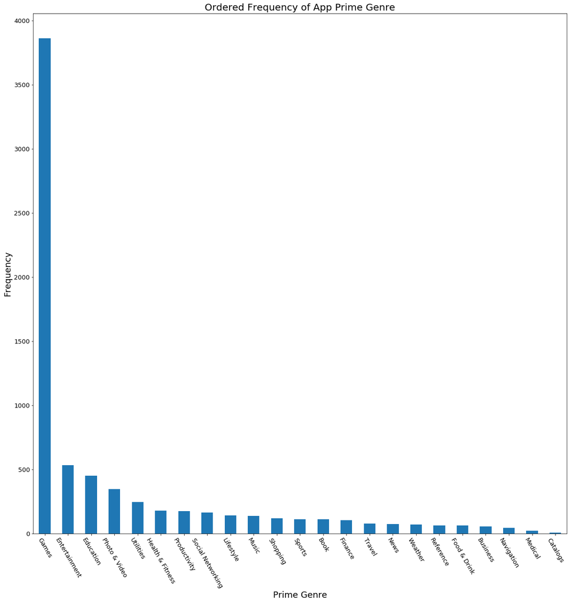

```python
combined_app_data.prime_genre.value_counts().plot.bar()
plt.title("Ordered Frequency of App Prime Genre", fontsize=20)
plt.xlabel("Prime Genre", fontsize=18)
plt.ylabel("Frequency", fontsize=18)
plt.yticks(fontsize=13)
plt.xticks(fontsize=13,rotation=(-60))
plt.show()
```

大部分的 App 類型集中在 game 中，在此將 Utilities 以下的所有 prime genre 合為 others 類型，方便後續分析。

```python
prime_genre_df = combined_app_data.prime_genre.value_counts().index[:4]
combined_app_data['broad_genre']= combined_app_data.prime_genre.apply(lambda x : x if x in prime_genre_df else "Others")
combined_app_data.head()
```

| id | track_name | size_bytes | currency | price | rating_count_tot | rating_count_ver | user_rating | user_rating_ver | ver | cont_rating | prime_genre | sup_devices.num | ipadSc_urls.num | lang.num | vpp_lic | app_desc | Category | desc_len | broad_genre |
| --- | --- | --- | --- | --- | --- | --- | --- | --- | --- | --- | --- | --- | --- | --- | --- | --- | --- | --- | --- |
| 281656475 | PAC-MAN Premium | 100788224 | USD | 3.99 | 21292 | 26 | 4.0 | 4.5 | 6.3.5 | 4+ | Games | 38 | 5 | 10 | 1 | SAVE 20%, now only $3.99 for a limited time!\n... | Paid app | 1533 | Games |
| 281796108 | Evernote - stay organized | 158578688 | USD | 0.00 | 161065 | 26 | 4.0 | 3.5 | 8.2.2 | 4+ | Productivity | 37 | 5 | 23 | 1 | Let Evernote change the way you organize your ... | Free app | 3952 | Others |
| 281940292 | WeatherBug - Local Weather, Radar, Maps, Alerts | 100524032 | USD | 0.00 | 188583 | 2822 | 3.5 | 4.5 | 5.0.0 | 4+ | Weather | 37 | 5 | 3 | 1 | Download the most popular free weather app pow... | Free app | 2090 | Others |
| 282614216 | eBay: Best App to Buy, Sell, Save! Online Shop... | 128512000 | USD | 0.00 | 262241 | 649 | 4.0 | 4.5 | 5.10.0 | 12+ | Shopping | 37 | 5 | 9 | 1 | The eBay app is the best way to find anything ... | Free app | 3997 | Others |
| 282935706 | Bible | 92774400 | USD | 0.00 | 985920 | 5320 | 4.5 | 5.0 | 7.5.1 | 4+ | Reference | 37 | 5 | 45 | 1 | On more than 250 million devices around the wo... | Free app | 2998 | Others |

# 分析

## 不同類型的 App 之下，是否付費的會得到較高的評分？

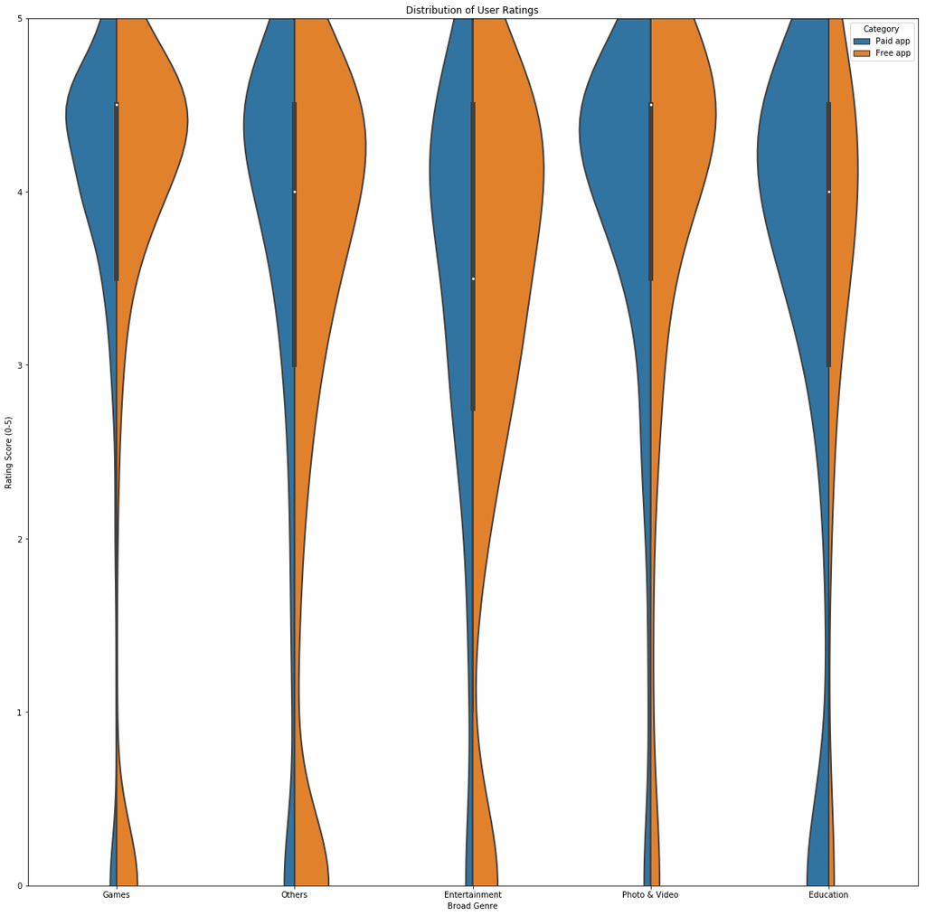

```python
plt.figure()
plt.ylim([0,5])
plt.title("Distribution of User Ratings")
sns.violinplot(data=combined_app_data, y ='user_rating',x='broad_genre',hue='Category',
               vertical=True,kde=False,split=True ,linewidth=2,
               scale ='count')
plt.xlabel("Broad Genre")
plt.ylabel("Rating Score (0-5)")
plt.show()
```

由上圖可看出，不論何種類型的 App，付費與否的分配皆十分類似，也大部分位於 2.5 分以上的評分。

```python
combined_app_data.user_rating.value_counts().reset_index().T
```

|  | 0 | 1 | 2 | 3 | 4 | 5 | 6 | 7 | 8 | 9 |
| --- | --- | --- | --- | --- | --- | --- | --- | --- | --- | --- |
| index | 4.5 | 4.0 | 0.0 | 3.5 | 5.0 | 3.0 | 2.5 | 2.0 | 1.5 | 1.0 |
| user_rating | 2663.0 | 1626.0 | 929.0 | 702.0 | 492.0 | 383.0 | 196.0 | 106.0 | 56.0 | 44.0 |

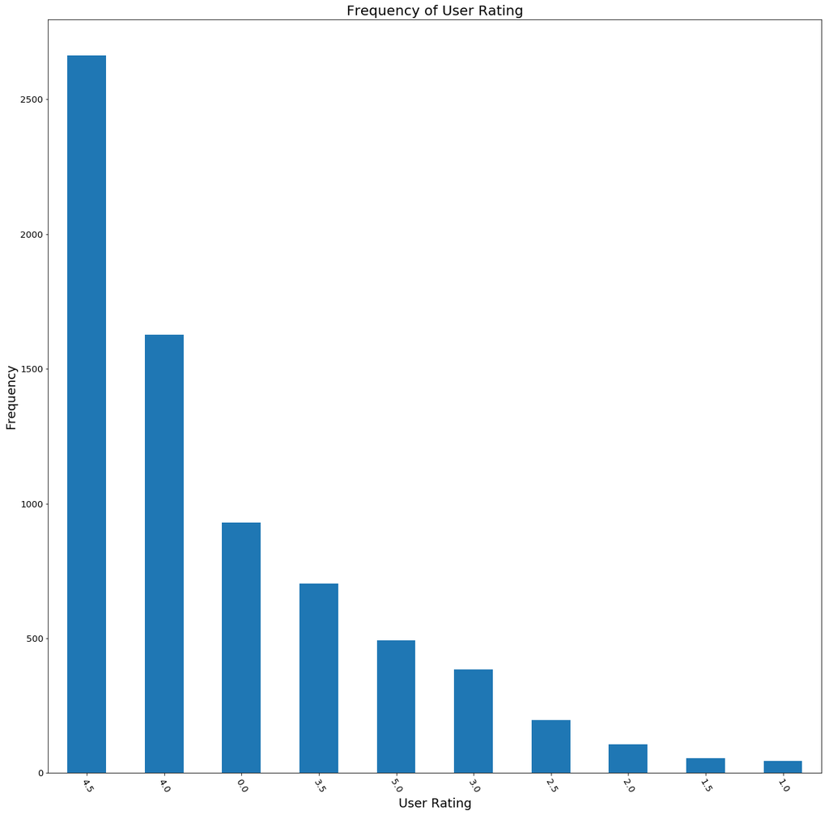

```python
combined_app_data.user_rating.value_counts().plot.bar()
plt.title("Frequency of User Rating", fontsize=20)
plt.xlabel("User Rating", fontsize=18)
plt.ylabel("Frequency", fontsize=18)
plt.yticks(fontsize=13)
plt.xticks(fontsize=13,rotation=(-60))
plt.show()
```

由上圖可知，大部分的評分皆位於 2.5 分以上，使用者在作出評分動作時，大部分會評出較高的分數。

總合以上兩圖的結論，使用者在評分時，大部分會評出較高的分數，不論付費與否或者是哪種類型的 App，皆有此趨勢。

## App 類型是否會影響收益？

在此將收益的定義為：rating_count_tot * price => 因為會進行評論的，一般而言為已購買 app 的使用者

```python
combined_app_data['revenue'] = combined_app_data.rating_count_tot * combined_app_data.price
revenue_sorted = combined_app_data.sort_values(by="revenue", ascending=False).head(10).reset_index()
revenue_sorted.loc[:, ["track_name", "rating_count_tot", "price", "revenue", "prime_genre"]].T
```

|  | 0 | 1 | 2 | 3 | 4 | 5 | 6 | 7 | 8 | 9 |
| --- | --- | --- | --- | --- | --- | --- | --- | --- | --- | --- |
| track_name | Minecraft: Pocket Edition | Fruit Ninja Classic | Draw Something | SCRABBLE Premium | Call of Duty: Black Ops Zombies | TuneIn Radio Pro - MLB Audiobooks Podcasts Music | Clear Vision (17+) | Geometry Dash | Terraria | Plants vs. Zombies |
| rating_count_tot | 522012 | 698516 | 360974 | 105776 | 116601 | 71609 | 541693 | 266440 | 98036 | 426463 |
| price | 6.99 | 1.99 | 2.99 | 7.99 | 6.99 | 9.99 | 0.99 | 1.99 | 4.99 | 0.99 |
| revenue | 3.64886e+06 | 1.39005e+06 | 1.07931e+06 | 845150 | 815041 | 715374 | 536276 | 530216 | 489200 | 422198 |
| prime_genre | Games | Games | Games | Games | Games | Music | Games | Games | Games | Games |

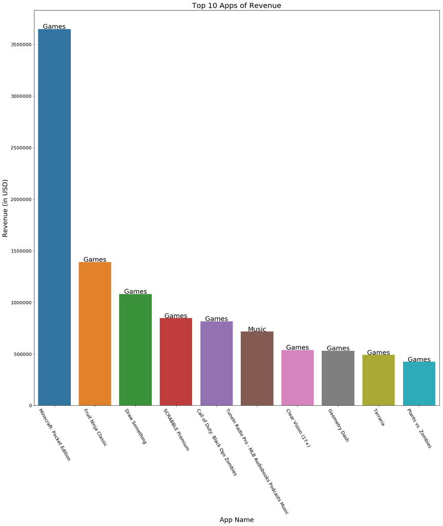

```python
bar_titles = revenue_sorted["prime_genre"]
sns.barplot(x=revenue_sorted.track_name, y=revenue_sorted.revenue)
plt.title("Top 10 Apps of Revenue", fontsize=20)
plt.xlabel("App Name", fontsize=18)
plt.ylabel("Revenue (in USD)", fontsize=18)
plt.yticks(fontsize=13)
plt.xticks(fontsize=13,rotation=(-60))
for x,y in enumerate(revenue_sorted.revenue):
    plt.text(x,y+3000,'%s' %bar_titles[x], fontsize=18,ha='center')
plt.show()
```